# Reproducible Research – Assignment 1

## R Markdown

```r
d=read.csv(file="C:/Temp/repdata_data_activity/activity.csv",sep= ",", h=T)
```

#### 1.1. Calculate the total number of steps taken per day

```r
#d
#summary(d)
#nrow(d)

#d1 <- aggregate(d[, 1], list(d$date), sum)

library(plyr)
d_1 <- ddply(d, ~date, summarise, total_steps_per_day=sum (steps) , rm.na = TRUE )
d_1
```

```
##          date total_steps_per_day rm.na
## 1  2012-10-01                  NA  TRUE
## 2  2012-10-02                 126  TRUE
## 3  2012-10-03               11352  TRUE
## 4  2012-10-04               12116  TRUE
## 5  2012-10-05               13294  TRUE
## 6  2012-10-06               15420  TRUE
## 7  2012-10-07               11015  TRUE
## 8  2012-10-08                  NA  TRUE
## 9  2012-10-09               12811  TRUE
## 10 2012-10-10                9900  TRUE
## 11 2012-10-11               10304  TRUE
## 12 2012-10-12               17382  TRUE
## 13 2012-10-13               12426  TRUE
## 14 2012-10-14               15098  TRUE
```

[output cut: 47 more lines]

#### 1.2. Histogram of the total number of steps taken each day

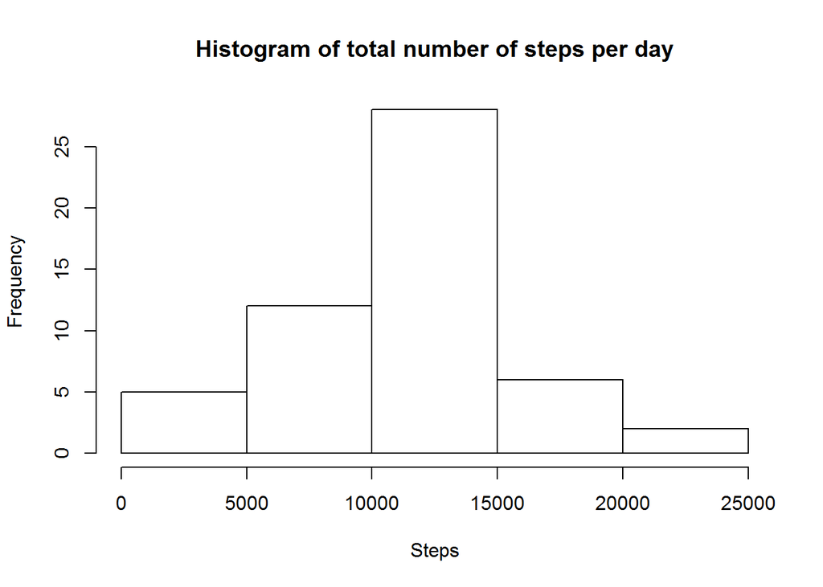

```r
hist(d_1$total_steps_per_day, main="Histogram of total number of steps per day", xlab = "Steps")
```

```r
d_2 <- ddply(d, ~date, summarise, mean_steps=mean(steps), median_steps= median(steps) , rm.na = TRUE )

d_2
```

```
##          date mean_steps median_steps rm.na
## 1  2012-10-01         NA           NA  TRUE
## 2  2012-10-02  0.4375000            0  TRUE
## 3  2012-10-03 39.4166667            0  TRUE
## 4  2012-10-04 42.0694444            0  TRUE
## 5  2012-10-05 46.1597222            0  TRUE
## 6  2012-10-06 53.5416667            0  TRUE
## 7  2012-10-07 38.2465278            0  TRUE
## 8  2012-10-08         NA           NA  TRUE
## 9  2012-10-09 44.4826389            0  TRUE
## 10 2012-10-10 34.3750000            0  TRUE
## 11 2012-10-11 35.7777778            0  TRUE
## 12 2012-10-12 60.3541667            0  TRUE
## 13 2012-10-13 43.1458333            0  TRUE
## 14 2012-10-14 52.4236111            0  TRUE
```

[output cut: 47 more lines]

```r
#mean (d1$x, na.rm = TRUE )
#median (d1$x, na.rm = TRUE )
```

### 2. What is the average daily activity pattern?

#### 2.1. Make a time series plot of the 5-minute interval (x-axis) and the average number of steps taken, averaged across all days (y-axis)

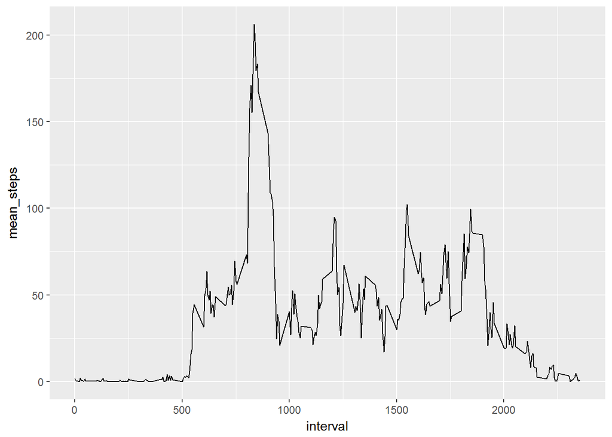

```r
require(ggplot2)
require(scales)
library(ggplot2)

ggplot(data=d_3, aes(x= interval, y=mean_steps, group =1)) + geom_line()
```

#### 2.2. Which 5-minute interval, on average across all the days in the dataset, contains the maximum number of steps?

```r
d_3$mx <- max(d_3$mean_steps, na.rm= true)

newdata <- unique( subset (d_3, d_3$mean_steps == d_3$mx) )
newdata
```

```
##     interval mean_steps rm.na       mx
## 104      835   206.1698  TRUE 206.1698
```

At the inverval of **835** contains the maximum number of steps.

### 3.Imputing missing values

#### 3.1. Calculate and report the total number of missing values in the dataset (i.e. the total number of rows with NAs)

```r
n <- sum(is.na(d$steps) | is.na(d$date) | is.na(d$interval))
n
```

```
## [1] 2304
```

There are **2304** missing values in the dataset

#### 3.2. filling in all of the missing values in the dataset, replace missing value with mean steps of the day

#### 3.3. Create a new dataset that is equal to the original dataset but with the missing data filled in.

```r
#n1 <- sum(is.na(d$steps))
#n1
rplc<- merge (d, d_2, by = "date")
rplc$steps[is.na(rplc$steps)] <- rplc$mean_steps
n2<-sum(is.na(rplc$steps))
n2
```

```
## [1] 576
```

The missing data is replaced with the means steps of the day. The dataset with missing data filled in is created. Now there are only **576** missing data points, used to be 2304 missing data points.

```r
rplc1 <- ddply(rplc, ~date, summarise, total_steps=sum(steps))

as.numeric(rplc1$total_steps)
```

```
##  [1]    NA   126 11352 12116 13294 15420 11015   126 12811  9900 10304
## [12] 17382 12426 15098 10139 15084 13452 10056 11829 10395  8821 13460
## [23]  8918  8355  2492  6778 10119 11458  5018  9819 15414 11352 10600
## [34] 10571 12116 10439  8334 12883  3219 13294 15420 12608 10765  7336
## [45] 11015    41  5441 14339 15110  8841  4472 12787 20427 21194 14478
## [56] 11834 11162 13646 10183  7047    NA
```

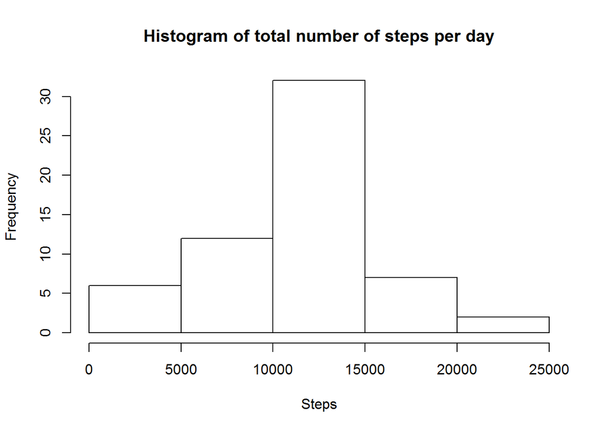

```r
hist(rplc1$total_steps, main= "Histogram of total number of steps per day", xlab= "Steps")
```

THe dataset filled with mean value now constains only 2 missing data points, while the original data contains 8.

### 4. Are there differences in activity patterns between weekdays and weekends?

#### 4.1 Create a new factor variable in the dataset with two levels - “weekday” and “weekend” indicating whether a given date is a weekday or weekend day.

```r
library(chron)

rplc$wk = ifelse (chron::is.weekend(rplc$date), "weekend", "weekday")
```

#### 4.2. A panel plot containing a time series plot of the 5-minute interval (x-axis) and the average number of steps taken, averaged across all weekday days or weekend days (y-axis).

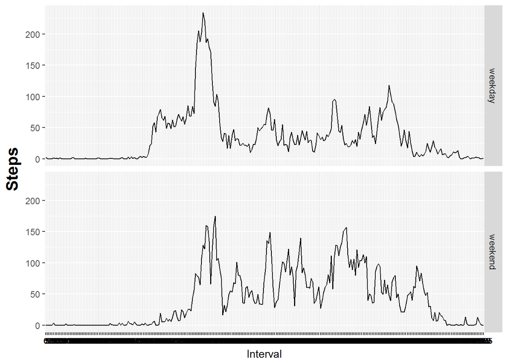

```r
ggplot(rplc_nona, aes(x= interval,y=mean_s_w_I, group=1)) +geom_line() +
        facet_grid(factor(wk) ~ .) +
    xlab("Interval") +
    ylab( "Steps") +
    theme(axis.title.y = element_text(face='bold',size=16,vjust=1),
          axis.text.x = element_text(face='bold',size=8,color='black'))
```